# Advantage of two scans in small populations demonstrated with a transgender dataset.

Freya Acar

# Overview

1. Introduction
2. Startup
3. Descriptives
4. Analysis
   - Analysis of one measurement
   - Analysis of the average
   - Post-hoc t-tests
5. Correlations between T1 and T2
6. Simulations
7. Discussion

## Introduction

We have a dataset where FreeSurfer was used to determine cortical and subcortical brain anatomy in cis- and transgender population. For every participant two scans were administered (T1 and T2) and an average of both scans was computed. In this report we analyze the data from one scan and the average of both scans. Later on we show the advantage and increase in power obtained by admninistering 2 scans.  
One participant (P22) was removed from the analysis because no anatomical data was available for this participant.

## Startup

We first read in the data. In data.all all available measurements are stored (descriptive and anatomical) while in data.hyp the anatomical results for every region of interest stored. Both files contain data of T1, T2 and the average.

```r
# Libraries
library(knitr)

# Read in data
data.all <- read.csv("../1.Data/Behzad_all.csv", sep=";", dec=",")
data.hyp <- read.csv("../1.Data/Behzad_hyp.csv", sep=";", dec=",")

# Check data
dim(data.hyp)
```

```
## [1] 140  68
```

```r
dim(data.all)
```

```
## [1] 140 820
```

The regions we are interested in are the cerebellum, caudate, putamen, nucleus accumenbens, thalamus, fusiform, pre-central gyrus, post-central gyrus, frontal poles and inferior parietal gyrus. Here we list the variables we selected from FreeSurfer that comply with these regions.

```r
# Regions of interest
names(data.hyp[,47:68])
```

```
##  [1] "Tavg_L_fusiform_volume"          "Tavg_L_inferiorparietal_volume"
##  [3] "Tavg_L_postcentral_volume"       "Tavg_L_precentral_volume"
##  [5] "Tavg_L_frontalpole_volume"       "Tavg_R_fusiform_volume"
##  [7] "Tavg_R_inferiorparietal_volume"  "Tavg_R_postcentral_volume"
##  [9] "Tavg_R_precentral_volume"        "Tavg_R_frontalpole_volume"
## [11] "Tavg_LeftCerebellumWhiteMatter"  "Tavg_LeftCerebellumCortex"
## [13] "Tavg_RightCerebellumWhiteMatter" "Tavg_RightCerebellumCortex"
## [15] "Tavg_LeftThalamusProper"         "Tavg_LeftCaudate"
## [17] "Tavg_LeftPutamen"                "Tavg_LeftAccumbensarea"
## [19] "Tavg_RightThalamusProper"        "Tavg_RightCaudate"
## [21] "Tavg_RightPutamen"               "Tavg_RightAccumbensarea"
```

## Descriptives

In this section population parameters are presented.

### Gender

There were 60 cisgender and 80 transgender participants. One participant (P22) was removed from the analysis because no anatomical data was available for this participant.

```r
ng1 <- sum(data.all[,2]==1)
ng2 <- sum(data.all[,2]==2)
ng3 <- sum(data.all[,2]==3)
ng4 <- sum(data.all[,2]==4)

paste("Cisgender women = ", ng1, ", cisgender men = ", ng2,
      ", transgender men = ", ng3, ", transgender women = ",ng4, sep="")
```

```
## [1] "Cisgender women = 30, cisgender men = 30, transgender men = 40, transgender women = 40"
```

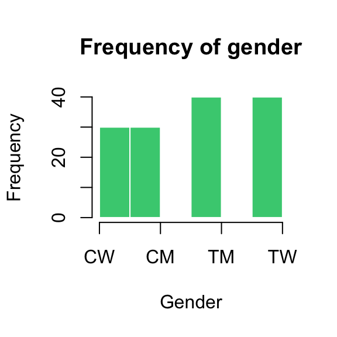

```r
hist(data.all[,2], breaks = 5, xlab = "Gender", xaxt = "n", col = "seagreen3",
     border = "white", main = "Frequency of gender")
axis(1,at=c(1:4),labels=c("CW", "CM", "TM", "TW"))
```